# Intro to R for Epidemiologists

Lab 12

Your name

Thursday, April 9, 2015

For this lab, you will use R Markdown and `knitr` to recreate this report. Your lab only needs to include the header (above this paragraph) and the numbered sections below starting with *Introduction*. You will need the `diabetes` dataset from lab 8 and the `tab_diab` object from Homework 1.

Instructions:

1. Create a header with title, subtitle, author, and date
2. Change the options for the html_document output to allow figure captions, numbered sections, and a table of contents. Additionally, change the theme to cosmo.
3. In a code chunk, set global `knitr` options and load all the packages you need.
4. In a code chunk, read in your dataset `diabetes.csv` and read the chunks for the two external files `exfile1.R` and `exfile2.R`.
5. Use the information in `exfile1.R` and `exfile2.R` to bring in the chunks corresponding to the Tables and Figure. Note: you should not have any R code written in this file in the Tables and Figure section.
6. Set up the Introduction, Tables, and Figure sections.
7. Set up the Function section. Hint: In the file `exfile1.R`, I’ve created an R object called `cat1`. Use in-line text to include this picture in the output file.

# 1 Introduction

The `diabetes` dataset has 403 observations and 20 variables. In this report, we create:

1. A table displaying means and number of observations for the diabetes dataset as in Homework 1.
2. A table displaying the odds ratios for the diabetes dataset as in Lab 8.
3. A plot displaying the odds ratios from Table 2 and corresponding 95% confidence intervals.

# 2 Tables

Table 1. Summary statistics

| Variable | Mean | N_diabetic | Mean_diabetic | N_not_diabetic |
| --- | --- | --- | --- | --- |
| chol | 207.85 | 60 | 228.60 | 329 |
| hdl | 50.45 | 60 | 45.28 | 329 |
| age | 46.85 | 60 | 58.40 | 330 |
| height | 66.02 | 59 | 66.17 | 326 |
| weight | 177.59 | 59 | 192.71 | 330 |

Table 2. Odds ratios

| Variable | OR | p-value | LB | UB |
| --- | --- | --- | --- | --- |
| chol | 1.01 | 0.00 | 1.00 | 1.02 |
| hdl | 0.98 | 0.02 | 0.96 | 1.00 |
| age | 1.06 | 0.00 | 1.04 | 1.08 |
| weight | 1.01 | 0.01 | 1.00 | 1.02 |
| height | 1.01 | 0.77 | 0.93 | 1.10 |

# 3 Figure

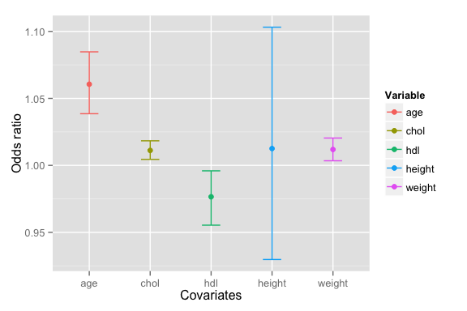

Figure 1. Associations between covariates and diabetes

# 4 Functions

Cute cat function courtesy of Scott Chamberlain http://rforcats.net/.

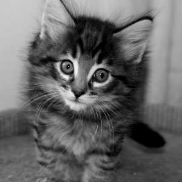